# Introdução à Ciência de Dados

Aula 4

Autor

Data de Publicação

24 de abril de 2025

# 1 Pacotes Necessários

```r
# carrega os pacotes necessários
library(tidyverse)
library(readxl)
library(xts)
library(plm)
```

# 2 Dados Organizados (*Tidy Data*)

## 2.1 Dados **wide** (largos) e **long** (longos)

**Exemplo 1**: Suponha que tenhamos três pacientes com identidades A, B e C e que foram realizadas duas medições de pressão arterial em cada paciente:

```r
df <- tribble(
  ~id, ~bp1, ~bp2,
  "A", 100, 120,
  "B", 140, 115,
  "C", 120, 125
)

df
```

```
# A tibble: 3 × 3
  id      bp1   bp2
  <chr> <dbl> <dbl>
1 A       100   120
2 B       140   115
3 C       120   125
```

Este é o caso mais comum de problemas em dados desorganizados, em que os **valores** de uma variável (medição) são usados como nomes de colunas (variáveis).

Para os dados estarem organizados teríamos 3 variáveis:

- `id` (já existe),
- `medição` (os nomes das colunas) e
- `valor` (os valores das células).

Para conseguir isso, precisamos *alongar* (*lengthening*) os dados:

```r
# Transformando os dados de formato wide para formato long
df_long <- df |>
  tidyr::pivot_longer(
    cols = bp1:bp2,
    names_to = "medicao",
    values_to = "valor"
  )

df_long
```

```
# A tibble: 6 × 3
  id    medicao valor
  <chr> <chr>   <dbl>
1 A     bp1       100
2 A     bp2       120
3 B     bp1       140
4 B     bp2       115
5 C     bp1       120
6 C     bp2       125
```

**Exemplo 2**: Suponha que temos uma tabela com dados de receita trimestral para diferentes produtos:

```r
# Criando a `tribble`
receitas <- tribble(
  ~produto, ~Q1, ~Q2, ~Q3, ~Q4,
  "Produto A", 50000, 55000, 60000, 65000,
  "Produto B", 30000, 32000, 35000, 37000,
  "Produto C", 20000, 22000, 25000, 27000
)

receitas
```

```
# A tibble: 3 × 5
  produto      Q1    Q2    Q3    Q4
  <chr>     <dbl> <dbl> <dbl> <dbl>
1 Produto A 50000 55000 60000 65000
2 Produto B 30000 32000 35000 37000
3 Produto C 20000 22000 25000 27000
```

Novamente, podemos ver que os valores de uma variável (`trimestre``) são usados como nomes de colunas.

Vamos organizar os dados

```r
# Transformando os dados de formato wide para formato long
receitas_long <- receitas %>%
  tidyr::pivot_longer(
    cols = Q1:Q4,
    names_to = "trimestre",
    values_to = "receita"
  )

receitas_long
```

```
# A tibble: 12 × 3
   produto   trimestre receita
   <chr>     <chr>       <dbl>
 1 Produto A Q1          50000
 2 Produto A Q2          55000
 3 Produto A Q3          60000
 4 Produto A Q4          65000
 5 Produto B Q1          30000
 6 Produto B Q2          32000
 7 Produto B Q3          35000
 8 Produto B Q4          37000
 9 Produto C Q1          20000
10 Produto C Q2          22000
11 Produto C Q3          25000
12 Produto C Q4          27000
```

# 3 Tipos Básicos e Classes de Dados em R

## 3.1 A Importância de Conhecer Tipos e Classes de Dados

Se os métodos de análise estatística dependem da escala de medição (tipo) de uma variável de interesse, compreender os tipos e classes de dados da linguagem R (ou de qualquer outra) é fundamental.

Cada tipo de análise ou de gráfico exige que as variáveis sejam de um tipo ou classe específicos e estejam organizadas em uma estrutura de dados específica.

Na prática da ciência ou análise de dados, estima-se que analistas e cientistas dedicam entre 60% a 80% do tempo de um projeto à importação, limpeza e preparação dos dados antes de iniciar as análises.

## 3.2 Classe `factor`: Variável Categórica Nominal

- A classe `factor` da linguagem R é apropriada para representar variáveis categóricas nominais ou ordinais.

```r
# Cria um vetor de caracteres
estado_civil <- c(
  "Casado", "Solteiro", "Divorciado", "Solteiro",
  "Casado", "Viúvo", "Solteiro", "Divorciado"
)

# Converte para fator (variável categórica nominal)
estado_civil_fator <- factor(estado_civil)

# Vizualizando o objetoa
estado_civil_fator
```

```
[1] Casado     Solteiro   Divorciado Solteiro   Casado     Viúvo      Solteiro
[8] Divorciado
Levels: Casado Divorciado Solteiro Viúvo
```

verificando a classe:

```r
class(estado_civil_fator)
```

```
[1] "factor"
```

## 3.3 Classe `factor`: Variável Categórica Ordinal

```r
# Vetor de texto com dados brutos
escolaridade <- c(
  "Médio", "Fundamental", "Superior", "Superior",
  "Médio", "Pós-graduação", "Fundamental", "Médio"
)

# Convertendo para fator ordenado com níveis explícitos
escolaridade_fator <- factor(escolaridade,
  levels = c("Fundamental", "Médio", "Superior", "Pós-graduação"),
  ordered = TRUE # indica que é um fator ordenado
)

# Visualizando o fator e sua estrutura
escolaridade_fator
```

```
[1] Médio         Fundamental   Superior      Superior      Médio
[6] Pós-graduação Fundamental   Médio
Levels: Fundamental < Médio < Superior < Pós-graduação
```

verificando a classe:

```r
class(escolaridade_fator)
```

```
[1] "ordered" "factor"
```

## 3.4 Vetores - exemplos

```r
# cria um vetor numérico manualmente
idades <- c(22, 25, 19, 30, 27)
idades
```

```
[1] 22 25 19 30 27
```

```r
# cria um vetor de caracteres
nomes <- c("Ana", "Bruno", "Carla", "Daniel", "Eduarda")
nomes
```

```
[1] "Ana"     "Bruno"   "Carla"   "Daniel"  "Eduarda"
```

```r
# cria um vetor lógico
aprovados <- c(TRUE, FALSE, TRUE, TRUE, FALSE)
aprovados
```

```
[1]  TRUE FALSE  TRUE  TRUE FALSE
```

## 3.5 Data Frames e Tibbles

- **Data frame**: Estrutura tabular (similar a uma planilha Excel)
- Coleção de vetores **de mesmo comprimento** mas que podem ser de **tipos diferentes**
- Cada coluna = um vetor = uma variável
- Cada linha = uma observação
- **Tibble**: Versão moderna de data frame do pacote `tibble` (parte do `tidyverse`)
- Mais consistente e previsível que as data frames
- Inclui o tipo de cada coluna ao imprimir
- Não converte strings em fatores automaticamente

## 3.6 Exemplo de data frame/tibble

```r
# cria vetores manualmente
idades <- c(22, 25, 19, 30, 27)
nomes <- c("Ana", "Bruno", "Carla", "Daniel", "Eduarda")
aprovados <- c(TRUE, FALSE, TRUE, TRUE, FALSE)

# a funcao data.frame cria uma data frame usando os vetores
dados <- data.frame(idades, nomes, aprovados)

# exibe a data frame criada
dados
```

```
  idades   nomes aprovados
1     22     Ana      TRUE
2     25   Bruno     FALSE
3     19   Carla      TRUE
4     30  Daniel      TRUE
5     27 Eduarda     FALSE
```

Importando e preparando os dados do caso da destilaria:

```r
## define o caminho relativo do arquivo no projeto RStudio
caminho <- here::here("dados/brutos/productionlog_sample.csv")

## importa o arquivo com a função read_csv
dados_destilaria <- readr::read_csv(caminho)

# preparando (limpando) os dados
dados_destilaria_limpos <- dados_destilaria %>%
  select(-MONTH) %>%
  rename(
    dia = DAY,
    mestre_responsavel = MANUFACTURER,
    tipo_produto = PRODUCT,
    turno = SHIFT,
    cor = COLOR,
    fornecedor_malte = MALTING,
    indicador_qualidade = TASTING,
  ) %>%
  # Em seguidda, convertemos cada variável para classes adequadas
  mutate(
    dia = as.numeric(dia),
    mestre_responsavel = as.factor(mestre_responsavel),
    tipo_produto = as.factor(tipo_produto),
    turno = as.factor(turno),
    cor = as.numeric(cor),
    fornecedor_malte = as.factor(fornecedor_malte),
    indicador_qualidade = as.numeric(indicador_qualidade)
  ) %>%
  drop_na()
```

A função head exibe as 6 primeiras linhas de um objeto:

```r
head(dados_destilaria_limpos)
```

```
# A tibble: 6 × 7
    dia mestre_responsavel tipo_produto      turno     cor fornecedor_malte
  <dbl> <fct>              <fct>             <fct>   <dbl> <fct>
1     1 Leonard            Junglivet         Morning  0.27 Inhouse
2     1 Carlson            Junglivet Premium Evening  0.27 Burns Best Ltd.
3     2 Leonard            Junglivet         Morning  0.28 Inhouse
4     2 Carlson            Junglivet         Evening  0.32 Inhouse
5     3 Leonard            Junglivet         Morning  0.32 Matro Ltd.
6     3 Carlson            Junglivet         Evening  0.28 Inhouse
# ℹ 1 more variable: indicador_qualidade <dbl>
```

Acessando uma coluna/cariável

A função tail exibe as 6 últimas linhas de um objeto:

```r
tail(dados_destilaria_limpos)
```

```
# A tibble: 6 × 7
    dia mestre_responsavel tipo_produto      turno     cor fornecedor_malte
  <dbl> <fct>              <fct>             <fct>   <dbl> <fct>
1     8 Gumble             Junglivet Premium Morning  0.3  Burns Best Ltd.
2     8 Leonard            Junglivet Premium Evening  0.3  Matro Ltd.
3     9 Carlson            Junglivet Premium Morning  0.3  Inhouse
4     9 Leonard            Junglivet Premium Evening  0.3  Inhouse
5    10 Carlson            Junglivet         Morning  0.35 Burns Best Ltd.
6    10 Leonard            Junglivet         Evening  0.26 Matro Ltd.
# ℹ 1 more variable: indicador_qualidade <dbl>
```

```r
# acessando a variavel indicador_qualidade
# acesse com $
dados_destilaria_limpos$indicador_qualidade
```

```
 [1] 895 879 938 900 917 900 934 951 852 850 991 950 863 936 996 978 989 999 831
[20] 822
```

```r
# acessando a variavel fornecedor_malte
dados_destilaria_limpos$indicador_qualidade
```

```
 [1] 895 879 938 900 917 900 934 951 852 850 991 950 863 936 996 978 989 999 831
[20] 822
```

Verificando a classedos dados

```r
class(dados_destilaria_limpos)
```

```
[1] "tbl_df"     "tbl"        "data.frame"
```

Ao importar dados, todo objeto lido por R como uma data frame, também será uma tibble.

# 4 Importação e Estruturação de Dados Típicos de Finanças

## 4.1 Dados em Secção-Cruzada

Importe o arquivo `dados_artigo_reveduc.xlsx` utlizando a função `readxl::read_xlsx` e nomeie o objeto como `dados_artigo`:

```r
# define o caminho relativo do arquivo unemployment.csv
path_dados_artigo <- here::here("dados/brutos/dados_artigo_reveduc.xlsx")

# importa o arquivo
dados_artigo <- readxl::read_xlsx(path_dados_artigo)

# verifica a estrutura do objeto
dplyr::glimpse(dados_artigo)
```

```
Rows: 83
Columns: 8
$ turma                            <chr> "2014.1", "2014.1", "2014.1", "2015.1…
$ cotas                            <chr> "A0", "A0", "A0", "A0", "L1", "A0", "…
$ periodo_letivo                   <chr> "2017", "2017", "2017", "2017", "2017…
$ onde_estudou                     <chr> "Sempe em Escola Publica", "Parte Esc…
$ sexo                             <chr> "Masculino", "Feminino", "Masculino",…
$ cor                              <chr> "Branca", "Branca", "Parda", "Parda",…
$ renda_familiar                   <dbl> 3, 2, 1, 1, 4, 2, 2, 2, 2, 3, 3, 4, 3…
$ coeficiente_rendimento_academico <dbl> 68, 6, 83, 83, 76, 70, 70, 70, 70, 70…
```

Estatísticas básicas:

```r
summary(dados_artigo)
```

```
    turma              cotas           periodo_letivo     onde_estudou
 Length:83          Length:83          Length:83          Length:83
 Class :character   Class :character   Class :character   Class :character
 Mode  :character   Mode  :character   Mode  :character   Mode  :character



     sexo               cor            renda_familiar
 Length:83          Length:83          Min.   :0.000
 Class :character   Class :character   1st Qu.:2.000
 Mode  :character   Mode  :character   Median :2.000
                                       Mean   :2.699
                                       3rd Qu.:3.500
                                       Max.   :7.000
 coeficiente_rendimento_academico
 Min.   : 6.00
 1st Qu.:70.00
 Median :73.00
 Mean   :72.41
 3rd Qu.:76.00
 Max.   :92.00
```

### 4.1.1 Preparação dos Dados

```r
# Alterando a classe/tipo das colunas
dados_artigo_analise <- dados_artigo |>
  transmute(
    turma = as.factor(turma),
    cotas = as.factor(cotas),
    periodo_letivo = as.factor(periodo_letivo),
    onde_estudou = as.factor(onde_estudou),
    sexo = as.factor(sexo),
    cor = as.factor(cor),
    renda_familiar = as.integer(renda_familiar),
    cra = as.numeric(coeficiente_rendimento_academico)
  )

# verifica a estrutura do objeto
dplyr::glimpse(dados_artigo_analise)
```

```
Rows: 83
Columns: 8
$ turma          <fct> 2014.1, 2014.1, 2014.1, 2015.1, 2014.1, 2014.1, 2014.1,…
$ cotas          <fct> A0, A0, A0, A0, L1, A0, A0, A0, A0, L5, A0, A0, A0, A0,…
$ periodo_letivo <fct> 2017, 2017, 2017, 2017, 2017, 2017, 2017, 2017, 2017, 2…
$ onde_estudou   <fct> "Sempe em Escola Publica", "Parte Escola Pública, Parte…
$ sexo           <fct> Masculino, Feminino, Masculino, Masculino, Masculino, M…
$ cor            <fct> Branca, Branca, Parda, Parda, Branca, Branca, Branca, B…
$ renda_familiar <int> 3, 2, 1, 1, 4, 2, 2, 2, 2, 3, 3, 4, 3, 3, 5, 2, 1, 1, 7…
$ cra            <dbl> 68, 6, 83, 83, 76, 70, 70, 70, 70, 70, 73, 79, 74, 74, …
```

Estatísticas básicas:

```r
summary(dados_artigo_analise)
```

```
    turma    cotas   periodo_letivo
 2014.1:23   A0:41   2017:83
 2015.1:25   L1: 7
 2016.1:35   L2:15
             L5:12
             L6: 8

                                        onde_estudou        sexo        cor
 Parte Escola Pública, Parte Escola Particular: 9    Feminino :26   Branca:47
 Sempe em Escola Publica                      :71    Masculino:57   Parda :28
 Sempre em Escola Particular                  : 3                   Preta : 8



 renda_familiar       cra
 Min.   :0.000   Min.   : 6.00
 1st Qu.:2.000   1st Qu.:70.00
 Median :2.000   Median :73.00
 Mean   :2.699   Mean   :72.41
 3rd Qu.:3.500   3rd Qu.:76.00
 Max.   :7.000   Max.   :92.00
```

## 4.2 Dados de Séries Temporais

### 4.2.1 Caso 1: Arquivo de Dados **Não** Contém Datas

O arquivo `unemployment.csv` contém 63 dados mensais sobre a taxa de desemprego civil dos EUA como porcentagem da força de trabalho para os anos 2012-2017, obtidos da base da dados do Federal Reserve Bank of Saint Louis.

Importe o arquivo `unemployment.csv` utlizando a função `readr::read_csv()` e nomeie o objeto como `dados_desemeprego`.

```r
# define o caminho relativo do arquivo unemployment.csv
path_unemployment <- here::here("dados/brutos/unemployment.csv")

# importa o arquivo
dados_desemprego <- readr::read_csv(path_unemployment)

# verifica a estrutura do objeto
dplyr::glimpse(dados_desemprego)
```

```
Rows: 63
Columns: 1
$ Unemployment <dbl> 8.8, 8.7, 8.4, 7.7, 7.9, 8.4, 8.6, 8.2, 7.6, 7.5, 7.4, 7.…
```

Verificando a classe do objeto:

```r
# verifica a classe do objeto
class(dados_desemprego)
```

```
[1] "spec_tbl_df" "tbl_df"      "tbl"         "data.frame"
```

Transforme `dados_desemprego` para a classe `ts` (de *time series*) indicando que os dados são mensais e o primeiro período é janeiro de 2012 e nomeie o objeto como `desemprego_ts`:

```r
# converte a data frame dados_desemprego em um objeto da classe ts
desemprego_ts <- ts(dados_desemprego, start = c(2012, 1), frequency = 12)

# verifica a classe do objeto
class(desemprego_ts)
```

```
[1] "ts"
```

Visualizando o conteúdo do objeto:

```r
desemprego_ts
```

```
     Jan Feb Mar Apr May Jun Jul Aug Sep Oct Nov Dec
2012 8.8 8.7 8.4 7.7 7.9 8.4 8.6 8.2 7.6 7.5 7.4 7.6
2013 8.5 8.1 7.6 7.1 7.3 7.8 7.7 7.3 7.0 7.0 6.6 6.5
2014 7.0 7.0 6.8 5.9 6.1 6.3 6.5 6.3 5.7 5.5 5.5 5.4
2015 6.1 5.8 5.6 5.1 5.3 5.5 5.6 5.2 4.9 4.8 4.8 4.8
2016 5.3 5.2 5.1 4.7 4.5 5.1 5.1 5.0 4.8 4.7 4.4 4.5
2017 5.1 4.9 4.6
```

Utilizando a função `as.xts` do pacote `xts`, converta o objeto `desemprego_ts` para um objeto da classe `xts` e nomeie este objeto como `desemprego_xts.`:

```r
# converte o objeto desemprego_ts para um objeto da classe xts
desemprego_xts <- as.xts(desemprego_ts)

# verifcica a classe do objeto
class(desemprego_xts)
```

```
[1] "xts" "zoo"
```

Visualizando o conteúdo do objeto:

```r
desemprego_xts
```

```
         Unemployment
jan 2012          8.8
fev 2012          8.7
mar 2012          8.4
abr 2012          7.7
mai 2012          7.9
jun 2012          8.4
jul 2012          8.6
ago 2012          8.2
set 2012          7.6
out 2012          7.5
nov 2012          7.4
dez 2012          7.6
jan 2013          8.5
fev 2013          8.1
mar 2013          7.6
abr 2013          7.1
mai 2013          7.3
jun 2013          7.8
jul 2013          7.7
ago 2013          7.3
set 2013          7.0
out 2013          7.0
nov 2013          6.6
dez 2013          6.5
jan 2014          7.0
fev 2014          7.0
mar 2014          6.8
abr 2014          5.9
mai 2014          6.1
jun 2014          6.3
jul 2014          6.5
ago 2014          6.3
set 2014          5.7
out 2014          5.5
nov 2014          5.5
dez 2014          5.4
jan 2015          6.1
fev 2015          5.8
mar 2015          5.6
```

[output cut: 9 more lines]

```
jan 2016          5.3
fev 2016          5.2
mar 2016          5.1
abr 2016          4.7
mai 2016          4.5
jun 2016          5.1
jul 2016          5.1
ago 2016          5.0
set 2016          4.8
out 2016          4.7
nov 2016          4.4
dez 2016          4.5
jan 2017          5.1
fev 2017          4.9
mar 2017          4.6
```

É sempre fundamental analisar gráficos de séries temporais:

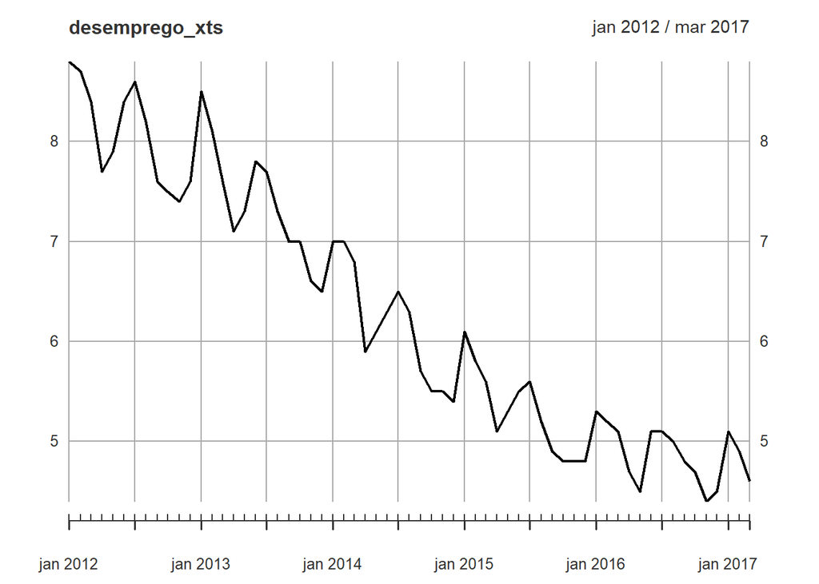

```r
plot(desemprego_xts)
```

## 4.3 Caso 2: Arquivo de Dados **Contém** Datas

O arquivo `ipeadata[06-04-2021-04-16].csv`, obtido no site [ipeadata](http://www.ipeadata.gov.br/Default.aspx) contém dados diários sobre a taxa de câmbio real/dólar, sendo que a primeira coluna contém os dias.

Podemos definir que a primeira coluna são dias usando o argumento `col_type()` da funcão `readr::read_csv2()`:

```r
# define o caminho relativo do arquivo
path_cambio <- here::here("dados/brutos/ipeadata[06-04-2021-04-16].csv")

# importa o arquivo ipeadata[06-04-2021-04-16].csv
dados_cambio <- readr::read_csv2(
  path_cambio,
  na = c(" "),
  skip = 1,
  locale = locale(decimal_mark = ","),
  col_names = c("dia", "real_dolar"),
  col_types = cols(dia = col_date(format = "%d/%m/%Y"), real_dolar = col_double())
)

# verifica a estrutura do objeto
dplyr::glimpse(dados_cambio)
```

```
Rows: 13,243
Columns: 3
$ dia        <date> 1985-01-02, 1985-01-03, 1985-01-04, 1985-01-05, 1985-01-06…
$ real_dolar <dbl> 1.152000e-09, 1.152000e-09, 1.152000e-09, NA, NA, 1.173818e…
$ X3         <lgl> NA, NA, NA, NA, NA, NA, NA, NA, NA, NA, NA, NA, NA, NA, NA,…
```

Verificando se há dados faltantes:

```r
summary(dados_cambio)
```

```
      dia               real_dolar        X3
 Min.   :1985-01-02   Min.   :0.0000   Mode:logical
 1st Qu.:1994-01-25   1st Qu.:0.1858   NA's:13243
 Median :2003-02-18   Median :1.8190
 Mean   :2003-02-18   Mean   :1.7745
 3rd Qu.:2012-03-12   3rd Qu.:2.6707
 Max.   :2021-04-05   Max.   :5.9366
                      NA's   :4171
```

Elimine a coluna `X3`, selecionando apenas as variáveis de interesse (`dia` e `real_dolar`) e retire os dados faltantes (`NA`):

```r
dados_cambio_limpos <- dados_cambio %>%
  select(dia, real_dolar) %>%
  drop_na()
summary(dados_cambio_limpos)
```

```
      dia               real_dolar
 Min.   :1985-01-02   Min.   :0.0000
 1st Qu.:1994-02-07   1st Qu.:0.1858
 Median :2003-02-26   Median :1.8190
 Mean   :2003-02-24   Mean   :1.7745
 3rd Qu.:2012-03-19   3rd Qu.:2.6707
 Max.   :2021-04-05   Max.   :5.9366
```

Utilizando a função `as.xts` do pacote `xts`, converta o objeto `dados_cambio_limpos` para um objeto da classe `xts` e nomeie este objeto como `cambio_xts.`

```r
cambio_xts <- as.xts(dados_cambio_limpos, order_by = dados_cambio_limpos$dia)
class(cambio_xts)
```

```
[1] "xts" "zoo"
```

Visualizando o conteúdo do objeto:

```r
cambio_xts
```

```
             real_dolar
1985-01-02 1.152000e-09
1985-01-03 1.152000e-09
1985-01-04 1.152000e-09
1985-01-07 1.173818e-09
1985-01-08 1.173818e-09
1985-01-09 1.173818e-09
1985-01-10 1.173818e-09
1985-01-11 1.200364e-09
1985-01-14 1.200364e-09
1985-01-15 1.200364e-09
       ...
2021-03-22 5.526300e+00
2021-03-23 5.494500e+00
2021-03-24 5.532400e+00
2021-03-25 5.657900e+00
2021-03-26 5.703600e+00
2021-03-29 5.791900e+00
2021-03-30 5.763600e+00
2021-03-31 5.696700e+00
2021-04-01 5.684300e+00
2021-04-05 5.657300e+00
```

É sempre fundamental analisar gráficos de séries temporais:

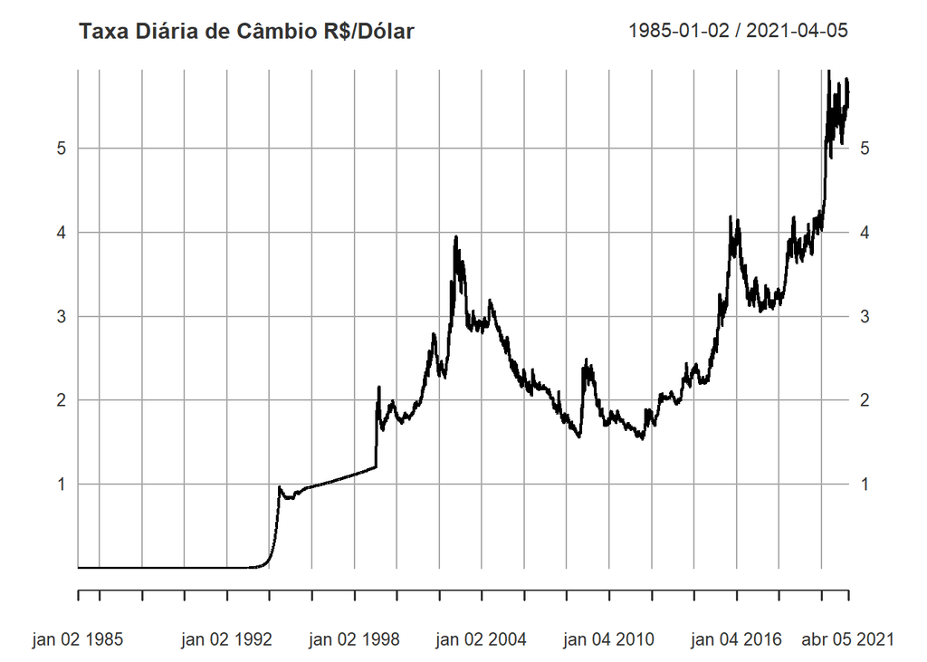

```r
plot(cambio_xts, main = "Taxa Diária de Câmbio R$/Dólar")
```

## 4.4 Dados em Painel

### 4.4.1 Dados em Painel com o Pacote `plm`

O arquivo `Data_AgricultureClimate.csv` contém um painel envolvendo 568 municípios paulistas com informações anuais (1990 a 2014) para o valor da produção agrícola (em R$), área agrícola, temperatura média e precipitação total no ano.

O arquivo contém as seguintes variáveis:

- `ano`: 1990 a 2014
- `munic`: código do município no IBGE
- `vtotal`: valor total da produçao agropecuária (R$)
- `areatotal`: área agrícola no município
- `tempano`: temperatura média no ano
- `precano`: precipitacao total no ano

Os autores estimaram variações para o seguinte modelo para as variáveis em estudo:

$$log(vtotal) = log(areatotal) + tempano + precano + erro$$

Importe o arquivo `Data_AgricultureClimate.csv` usando a função `readr::read_csv` e nomeie o objeto importando como `dados_agri`.

```r
# pacotes necessários
library(plm)

# define o caminho relativo do arquivo unemployment.csv
path_agri <- here::here("dados/brutos/Data_AgricultureClimate.csv")

# importa o arquivo
dados_agri <- readr::read_csv(path_agri)

# verifica a estrutura do objeto
dplyr::glimpse(dados_agri)
```

```
Rows: 14,200
Columns: 8
$ ano       <dbl> 1990, 1991, 1992, 1993, 1994, 1995, 1996, 1997, 1998, 1999, …
$ vtotal    <dbl> 1264258.8, 737239.9, 1381728.0, 1547278.9, 1383899.7, 163200…
$ areatotal <dbl> 1388970, 1235817, 1059597, 941193, 991584, 972081, 1063953, …
$ tempano   <dbl> 22.86265, 23.21814, 22.73152, 23.19672, 23.60301, 23.55167, …
$ tempanodp <dbl> 4.272846, 3.081071, 3.306779, 3.720999, 3.519357, 2.998808, …
$ precano   <dbl> 1316.3407, 1414.5173, 1389.9879, 1319.8478, 1160.3283, 1492.…
$ precanodp <dbl> 10.838446, 12.051548, 10.824051, 9.625086, 10.305651, 11.647…
$ munic     <dbl> 3500105, 3500105, 3500105, 3500105, 3500105, 3500105, 350010…
```

Declare o objeto como uma df para dados em painel usando a função `pdata.frame()` do pacote `plm`, nomeie o objeto criado como `agri_pd` e exiba a estrutura dos dados em painel usando a função `pdim`, também do pacote plm:

```r
agri_pd <- pdata.frame(dados_agri, index = c("munic", "ano"))
pdim(agri_pd)
```

```
Balanced Panel: n = 568, T = 25, N = 14200
```

Exibe as primeiras 26 obeservações do objeto `agri_pd`

```r
head(agri_pd, 26)
```

```
              ano    vtotal areatotal  tempano tempanodp   precano precanodp
3500105-1990 1990 1264258.8   1388970 22.86265  4.272846 1316.3407 10.838446
3500105-1991 1991  737239.9   1235817 23.21814  3.081071 1414.5173 12.051548
3500105-1992 1992 1381728.0   1059597 22.73152  3.306779 1389.9879 10.824051
3500105-1993 1993 1547278.9    941193 23.19672  3.720999 1319.8478  9.625086
3500105-1994 1994 1383899.7    991584 23.60301  3.519357 1160.3283 10.305651
3500105-1995 1995 1632009.4    972081 23.55167  2.998808 1492.4040 11.647982
3500105-1996 1996 1910847.5   1063953 23.02875  3.409370 1152.8168  9.131358
3500105-1997 1997 1843234.7   1081377 23.31529  3.296005 1567.5603 10.897275
3500105-1998 1998 1812944.3   1046529 23.19375  3.455135 1389.1166  9.438434
3500105-1999 1999 2051107.5   1094841 23.47183  3.518524  980.5187  7.462520
3500105-2000 2000 1326583.7    969804 23.27866  3.855466 1268.0232  8.863539
3500105-2001 2001 2484606.3   1234827 23.63068  3.524630 1290.8452  9.092621
3500105-2002 2002 3081434.7   1445895 24.46877  3.400730 1026.9569  8.730663
3500105-2003 2003 2546356.2   1342341 23.49745  3.403117 1180.7192  8.541839
3500105-2004 2004 2503896.5   1463121 23.04267  3.649041 1224.7500  9.831753
3500105-2005 2005 2861892.0   1419561 23.41364  3.296626 1247.0122  9.437955
3500105-2006 2006 3008258.9   1273536 23.80656  3.295634 1511.0146 11.559646
3500105-2007 2007 3909081.1   1403127 24.15558  3.471190 1282.3023  9.389535
3500105-2008 2008 3452473.9   1560042 23.34564  3.164526 1083.7051  8.418116
3500105-2009 2009 3702484.3   1592217 23.35703  3.509578 1940.9464 14.676315
3500105-2010 2010 3326064.9   1571823 23.09775  3.375724 1312.7949 10.246465
3500105-2011 2011 3284135.7   1525095 22.95209  3.536957 1130.9613  8.458459
3500105-2012 2012 3603019.6   1514700 23.34242  3.645005 1269.6732 10.613371
3500105-2013 2013 3572662.4   1501038 22.53909  3.439130 1277.4219 11.539546
3500105-2014 2014 2756874.7   1415898 23.16971  3.339900 1117.6440  8.803157
3500204-1990 1990 1042861.2    607860 23.03726  3.703297 1314.6804  9.024720
               munic
3500105-1990 3500105
3500105-1991 3500105
3500105-1992 3500105
3500105-1993 3500105
3500105-1994 3500105
3500105-1995 3500105
3500105-1996 3500105
3500105-1997 3500105
3500105-1998 3500105
3500105-1999 3500105
3500105-2000 3500105
3500105-2001 3500105
3500105-2002 3500105
3500105-2003 3500105
3500105-2004 3500105
3500105-2005 3500105
3500105-2006 3500105
3500105-2007 3500105
3500105-2008 3500105
3500105-2009 3500105
3500105-2010 3500105
3500105-2011 3500105
3500105-2012 3500105
3500105-2013 3500105
3500105-2014 3500105
3500204-1990 3500204
```